# Week 10 Lab. Correlation and Regression

Craig Enders

Friday December 4

■ data frame name ■ numeric variable ■ raw data file name

# The Data

These data come from a daily diary study of 61 young men living with HIV, between 16 and 24 years old, who completed a diary for 66 days (Ramirez et al., in preparation). The study examined the association between daily life stressors and negative mood. Each day, participants checked off which stressful events they had experienced from a list (for example, fights with family or friends, work stress, financial stress), and they completed the depression–dejection scale of the Profile of Mood States (POMS), which sums five questionnaire items so that higher scores reflect more negative mood.

Each row in the file is one participant: the daily reports were averaged across the 66 days, so every variable except `ID` and `HIVstress` is a person-level average. This lab asks whether participants who experience more daily stressors on average also report more depressed mood on average. It first looks at the correlations among five of the variables and then uses regression to examine whether the average number of daily stressors (`NumStressors`) predicts average depression (`Depress`). Correlation and regression are the tools for describing a trend between two numeric variables.

| Variable | Description | Scale |
| --- | --- | --- |
| `ID` | Individual identifier | Integer index |
| `HIVstress` | HIV-related stressors endorsed | Count (0 to 13) |
| `NumStressors` | Average number of daily stressors across the 66 diary days | Numeric (0.03 to 4.52) |
| `Support` | Average daily social support | Numeric (0 to 2.85) |
| `Tension` | Average daily POMS tension–anxiety score | Numeric (4 to 12.83) |
| `Depress` | Average daily POMS depression–dejection score | Numeric (4 to 12.91) |
| `Fatigue` | Average daily POMS fatigue score | Numeric (5.07 to 20) |
| `WellBeing` | Average daily well-being score | Numeric (3.30 to 13.89) |

Higher scores indicate more of each attribute. Every variable is numeric, so this lab has no categorical variables to convert to factors.

# Preliminaries: Loading Packages

R’s built-in functions handle basic statistics, but some tools in this lab come from add-on packages. `library()` makes a package’s functions available for the current session; it has to be run each time you open R, and it assumes the package was installed beforehand (see the Week 0 R Package Installation Script).

Two packages appear for the first time this week. The GGally package provides `ggpairs()`, which draws a matrix of scatterplots for several variables at once, and the estimatr package provides `lm_robust()`, which computes regression standard errors that do not assume constant residual variation. Both are in the Week 0 installation script.

```r
# estimatr provides lm_robust() for robust standard errors
library(estimatr)

# GGally provides ggpairs() for scatterplot matrices
library(GGally)

# ggplot2 draws the graphs
library(ggplot2)

# psych provides corr.test() for correlation matrices
library(psych)

# summarytools provides dfSummary() for data summaries
library(summarytools)

# rstudioapi talks to RStudio, used here to find the folder that contains this script
library(rstudioapi)
```

# Importing Data

There are two ways to get the data file into R. The document uses the first; the second is shown for reference because it is the one you will use with data files stored on your own computer.

## Option 1: Read From the Course Website

The data file lives on the course GitHub site. Store the web address in an object, then hand that address to `read.csv()`.

```r
# store the web address of the raw data file
filepath <- "https://raw.githubusercontent.com/craigenders/psych250a/main/data/DiaryMood.csv"

# read the file at that address into a data frame named DiaryMood
DiaryMood <- read.csv(filepath, stringsAsFactors = TRUE)
```

## Option 2: Read From the Folder That Contains the Script

When a data file is saved in the same folder as your R script, you can point R at that folder and then refer to the file by name alone. The rstudioapi package asks RStudio for the path of the script you are currently editing; `dirname()` strips the file name to leave the folder, and `setwd()` makes that folder R’s working directory. `getwd()` prints the working directory so you can confirm it landed where you expected. After that, `read.csv()` needs only the file name.

This block is displayed but not run, because a knitted document has no script to locate. Run it from an R script saved next to `DiaryMood.csv`. In the lab script the same lines are commented out; remove the leading `#` to use them.

```r
# set the working directory to the folder that contains this script
setwd(dirname(getActiveDocumentContext()$path))

# print the working directory to confirm the location
getwd()

# read DiaryMood.csv from the working directory into a data frame named DiaryMood
DiaryMood <- read.csv("DiaryMood.csv", stringsAsFactors = TRUE)
```

# Summarizing Data

`dfSummary()` from the summarytools package produces one row per variable showing its type, a compact summary of its values, a small graph of its distribution, and the number of valid and missing cases. In the HTML version of this lab, the table is handed to `print()` with `method = "render"` so that it displays as formatted HTML; that wrapper is not needed in your own documents.

```r
# overview of every variable in the data frame
print(dfSummary(DiaryMood), method = "render")
```

Data Frame Summary

DiaryMood

**Dimensions**: 61 x 8  
**Duplicates**: 0

| **No** | **Variable** | **Stats / Values** | **Freqs (% of Valid)** | **Graph** | **Valid** | **Missing** |
| --- | --- | --- | --- | --- | --- | --- |
| 1 | ID [integer] | Mean (sd) : 11460.3 (800) min ≤ med ≤ max: 10401 ≤ 11910 ≤ 12219 IQR (CV) : 1782 (0.1) | 61 distinct values |  | 61 (100.0%) | 0 (0.0%) |
| 2 | HIVstress [integer] | Mean (sd) : 6.6 (2.9) min ≤ med ≤ max: 0 ≤ 7 ≤ 13 IQR (CV) : 3 (0.4) | 13 distinct values |  | 61 (100.0%) | 0 (0.0%) |
| 3 | NumStressors [numeric] | Mean (sd) : 1.2 (1.1) min ≤ med ≤ max: 0 ≤ 0.9 ≤ 4.5 IQR (CV) : 1.6 (0.9) | 60 distinct values |  | 61 (100.0%) | 0 (0.0%) |
| 4 | Support [numeric] | Mean (sd) : 0.6 (0.6) min ≤ med ≤ max: 0 ≤ 0.4 ≤ 2.8 IQR (CV) : 0.6 (0.9) | 55 distinct values |  | 61 (100.0%) | 0 (0.0%) |
| 5 | Tension [numeric] | Mean (sd) : 6.4 (2.3) min ≤ med ≤ max: 4 ≤ 5.6 ≤ 12.8 IQR (CV) : 2.7 (0.4) | 60 distinct values |  | 61 (100.0%) | 0 (0.0%) |
| 6 | Depress [numeric] | Mean (sd) : 6.2 (2.1) min ≤ med ≤ max: 4 ≤ 5.6 ≤ 12.9 IQR (CV) : 2.6 (0.3) | 61 distinct values |  | 61 (100.0%) | 0 (0.0%) |
| 7 | Fatigue [numeric] | Mean (sd) : 9.6 (3.2) min ≤ med ≤ max: 5.1 ≤ 9 ≤ 20 IQR (CV) : 4.5 (0.3) | 60 distinct values |  | 61 (100.0%) | 0 (0.0%) |
| 8 | WellBeing [numeric] | Mean (sd) : 8.5 (2.5) min ≤ med ≤ max: 3.3 ≤ 8.2 ≤ 13.9 IQR (CV) : 3.6 (0.3) | 61 distinct values |  | 61 (100.0%) | 0 (0.0%) |

Generated by summarytools 1.1.5 ([R](https://www.r-project.org/) version 4.6.1)  
2026-11-24

All 61 participants have complete data. Several of the averages, including `NumStressors`, `Support`, and `Depress`, are right-skewed: most participants cluster at the low end, and a few report much higher values.

# Selecting Variables to Correlate

The next two functions work on every column of the data frame they receive, so the first step is to build a smaller data frame that holds only the variables to correlate. The square brackets select columns: `DiaryMood[, c(...)]` keeps every row (the empty space before the comma) and the named columns. The result is stored as a new data frame named `vars2corr`.

```r
# keep the five variables to correlate in a new data frame
vars2corr <- DiaryMood[, c("NumStressors", "Support", "Depress", "Fatigue", "WellBeing")]
```

# Scatterplot Matrix

A correlation summarizes a linear relationship with a single number, so it is worth looking at the scatterplots before trusting the numbers. `ggpairs()` from the GGally package draws every pairwise scatterplot in one figure. The three arguments control what appears in each part of the matrix:

- `upper` fills the panels above the diagonal; `wrap("cor", size = 5)` prints the correlation for each pair in a readable font size.
- `lower` fills the panels below the diagonal; `wrap("smooth", method = "lm", se = FALSE, alpha = 0.6)` draws the scatterplot with a straight regression line, omits the confidence band around the line, and makes the points partly transparent so overlapping points remain visible.
- `diag` fills the diagonal; `wrap("densityDiag")` draws a smoothed distribution of each variable.

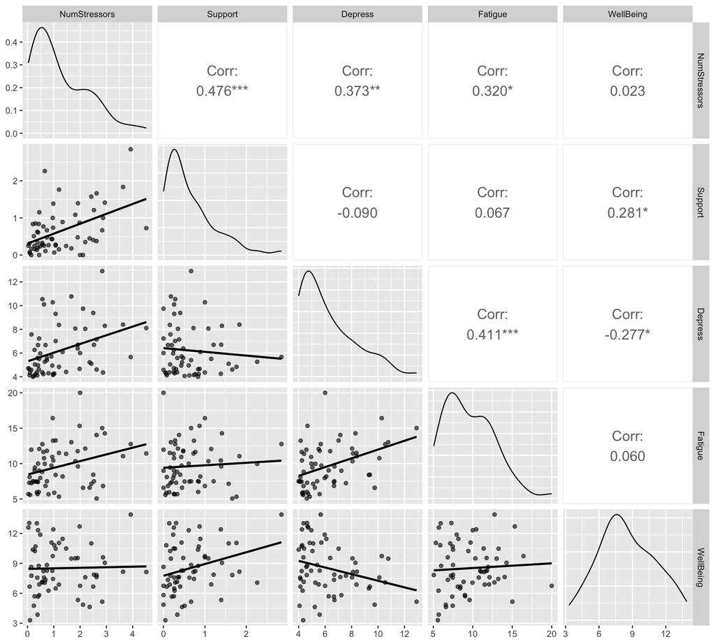

```r
# scatterplot matrix with correlations above the diagonal (GGally package)
ggpairs(vars2corr,
        upper = list(continuous = wrap("cor", size = 5)),
        lower = list(continuous = wrap("smooth", method = "lm", se = FALSE, alpha = 0.6)),
        diag = list(continuous = wrap("densityDiag")))
```

Each panel pairs the variable named in its column (horizontal axis) with the variable named in its row (vertical axis), and each correlation above the diagonal belongs to the scatterplot in the mirror-image position below it. The asterisks mark statistical significance (* *p* < .05, ** *p* < .01, *** *p* < .001) without any adjustment for the number of tests. The strongest relationships are between `NumStressors` and `Support` (*r* = .48), `Depress` and `Fatigue` (*r* = .41), and `NumStressors` and `Depress` (*r* = .37). Several scatterplots show a handful of participants far to the right of the others, which reflects the skewed distributions noted above.

# Correlation Matrix

`corr.test()` from the psych package computes the correlation matrix along with sample sizes, *p*-values, and confidence intervals. Handing the result to `print()` with `short = FALSE` adds the confidence intervals to the printout.

```r
# correlation matrix, confidence intervals, and p-values (psych package)
print(corr.test(vars2corr), short = FALSE)
```

```
Call:corr.test(x = vars2corr)
Correlation matrix
             NumStressors Support Depress Fatigue WellBeing
NumStressors         1.00    0.48    0.37    0.32      0.02
Support              0.48    1.00   -0.09    0.07      0.28
Depress              0.37   -0.09    1.00    0.41     -0.28
Fatigue              0.32    0.07    0.41    1.00      0.06
WellBeing            0.02    0.28   -0.28    0.06      1.00
Sample Size
[1] 61
Probability values (Entries above the diagonal are adjusted for multiple tests.)
             NumStressors Support Depress Fatigue WellBeing
NumStressors         0.00    0.00    0.02    0.08      1.00
Support              0.00    0.00    1.00    1.00      0.17
Depress              0.00    0.49    0.00    0.01      0.17
Fatigue              0.01    0.61    0.00    0.00      1.00
WellBeing            0.86    0.03    0.03    0.65      0.00

 Confidence intervals based upon normal theory.  To get bootstrapped values, try cor.ci
            raw.lower raw.r raw.upper raw.p lower.adj upper.adj
NmStr-Spprt      0.25  0.48      0.65  0.00      0.15      0.71
NmStr-Dprss      0.13  0.37      0.57  0.00      0.03      0.64
NmStr-Fatig      0.07  0.32      0.53  0.01     -0.02      0.59
NmStr-WllBn     -0.23  0.02      0.27  0.86     -0.23      0.27
Spprt-Dprss     -0.33 -0.09      0.17  0.49     -0.40      0.23
Spprt-Fatig     -0.19  0.07      0.31  0.61     -0.24      0.36
Spprt-WllBn      0.03  0.28      0.50  0.03     -0.06      0.56
Dprss-Fatig      0.18  0.41      0.60  0.00      0.07      0.66
Dprss-WllBn     -0.49 -0.28     -0.03  0.03     -0.55      0.05
Fatig-WllBn     -0.20  0.06      0.31  0.65     -0.23      0.34
```

The output has four parts:

- **Correlation matrix.** The Pearson correlation for every pair of variables. The matrix is symmetric, so each correlation appears twice.
- **Sample size.** The number of cases used for every correlation, 61 here.
- **Probability values.** The *p*-values. Entries below the diagonal are the usual unadjusted *p*-values; entries above the diagonal are adjusted for the number of tests (ten here) with Holm’s method, which plays the same role as the Tukey adjustment in the ANOVA lab: it holds the chance of any false positive across the whole set of tests near .05. Values print to two decimals, so a *p*-value shown as 0.00 is less than .005, not zero.
- **Confidence intervals.** One row per pair: `raw.r` is the correlation, `raw.lower` and `raw.upper` are its 95% confidence limits, `raw.p` is the unadjusted *p*-value, and `lower.adj` and `upper.adj` are confidence limits widened for the number of tests.

The correlation between the number of daily stressors and depression is *r* = .37, 95% CI [.13, .57], *p* = .003 (Holm-adjusted *p* = .02): participants who report more daily stressors also tend to report more depressed mood. Stressors are also positively correlated with social support (*r* = .48), perhaps because stressful days prompt people to seek support. The correlations of well-being with support (*r* = .28) and with depression (*r* = −.28) are significant before the adjustment but not after it.

# Scatterplot With Regression Line

The regression analysis below predicts depression from the number of daily stressors. A scatterplot with the regression line shows that relationship. The layers are:

- `ggplot(data = DiaryMood, aes(x = NumStressors, y = Depress))` names the data frame and maps the predictor to the horizontal axis and the outcome to the vertical axis.
- `geom_point(color = "blue")` draws one point per participant.
- `geom_smooth(method = "lm", color = "red")` draws the least-squares regression line. The shaded band is the 95% confidence interval for the predicted mean at each value of the predictor; it is narrowest near the middle of the data and widens toward the extremes, where there are fewer participants.

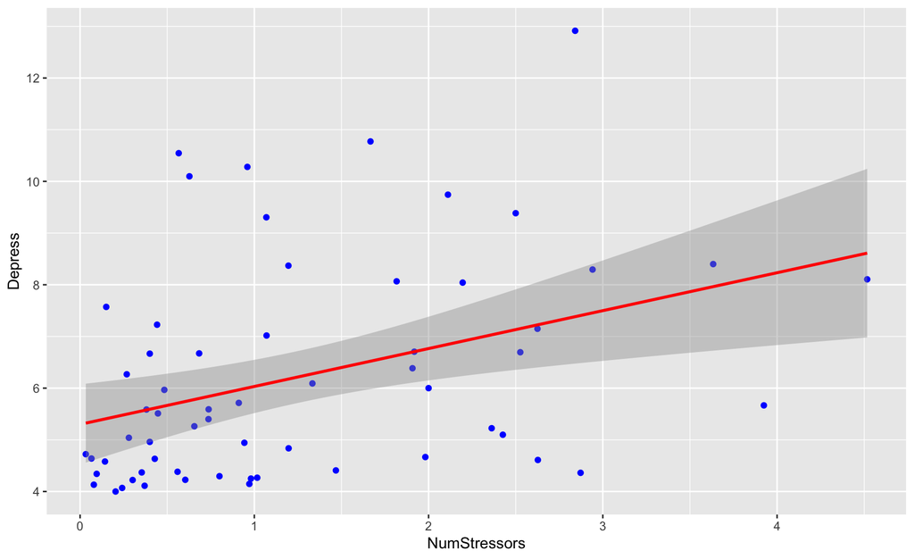

```r
# scatterplot with regression line (ggplot2 package)
ggplot(data = DiaryMood, aes(x = NumStressors, y = Depress)) +
  geom_point(color = "blue") +
  geom_smooth(method = "lm", color = "red")
```

The line rises from left to right, so higher stressor averages go with higher depression scores. The points scatter widely around the line, and several participants with few stressors have high depression scores, so the relationship is moderate rather than strong.

# Linear Regression

`lm()` fits a linear regression model from a formula with the outcome on the left of the tilde and the predictor on the right, the same formula style used by `t.test()` and `aov()`. The fitted model is stored in an object named `results`, and `summary()` prints the results. Storing the model matters because the confidence interval and residual functions below take the stored object as input.

```r
# linear regression of depression on the number of daily stressors (base R)
results <- lm(Depress ~ NumStressors, data = DiaryMood)
summary(results)
```

```
Call:
lm(formula = Depress ~ NumStressors, data = DiaryMood)

Residuals:
    Min      1Q  Median      3Q     Max
-3.0436 -1.3404 -0.4641  0.8722  5.5312

Coefficients:
             Estimate Std. Error t value             Pr(>|t|)
(Intercept)    5.2988     0.3877  13.666 < 0.0000000000000002 ***
NumStressors   0.7334     0.2371   3.093              0.00303 **
---
Signif. codes:  0 '***' 0.001 '**' 0.01 '*' 0.05 '.' 0.1 ' ' 1

Residual standard error: 1.96 on 59 degrees of freedom
Multiple R-squared:  0.1395,    Adjusted R-squared:  0.1249
F-statistic: 9.565 on 1 and 59 DF,  p-value: 0.003028
```

The `Coefficients` table has one row per coefficient. `Estimate` is the coefficient, `Std. Error` its standard error, `t value` the estimate divided by its standard error, and `Pr(>|t|)` the *p*-value.

Below the table, `Residual standard error` (1.96) is the typical distance between an observed depression score and the regression line. `Multiple R-squared` (.14) is the proportion of variance in depression that the predictor explains; with one predictor it equals the squared correlation (.37² ≈ .14). The *F* statistic tests the same null hypothesis as the slope’s *t*-test and equals *t*² (3.09² ≈ 9.57).

# Confidence Intervals for the Regression Coefficients

`confint()` computes 95% confidence intervals for the coefficients of the stored model.

```r
# 95% confidence intervals for the regression coefficients (base R)
confint(results)
```

```
                 2.5 %   97.5 %
(Intercept)  4.5229278 6.074675
NumStressors 0.2588819 1.207889
```

The interval for the slope runs from 0.26 to 1.21: the population slope is plausibly as small as a quarter of a point or as large as about one point per additional daily stressor. Zero is outside the interval, which agrees with the slope’s *p*-value. The interval is wide because the sample is small.

# Checking the Residuals

A residual is the distance between a participant’s observed score and the regression line. The *t*-tests and confidence intervals above assume that the residuals are normally distributed. `resid()` extracts the residuals from the stored model, and `hist()` draws their distribution.

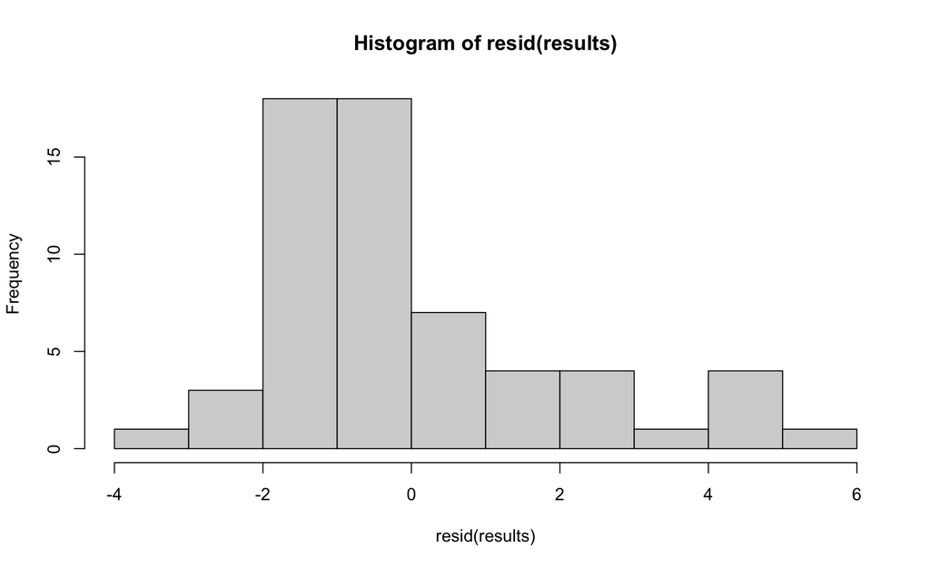

```r
# histogram of the regression residuals (base R)
hist(resid(results))
```

The residuals are right-skewed: most fall between about −3 and 1, and a few participants sit 4 or 5 points above the line. The skew mirrors the distribution of depression scores. With 61 participants the departure is worth noting, though it is not extreme.

# Sensitivity Check: Robust Standard Errors

The standard errors from `lm()` also assume that the residuals have the same variation at every value of the predictor (homoscedasticity), the regression version of the equal-variance assumption behind the classic *t* and *F* tests. `lm_robust()` from the estimatr package fits the same model with heteroscedasticity-robust standard errors, which do not make that assumption, in the same way that Welch’s tests relaxed the equal-variance assumption in the previous two labs. `se_type = "HC3"` requests the version that performs best in small samples.

```r
# regression with heteroscedasticity-robust standard errors (estimatr package)
results_robust <- lm_robust(Depress ~ NumStressors, data = DiaryMood, se_type = "HC3")
summary(results_robust)
```

```
Call:
lm_robust(formula = Depress ~ NumStressors, data = DiaryMood,
    se_type = "HC3")

Standard error type:  HC3

Coefficients:
             Estimate Std. Error t value                     Pr(>|t|) CI Lower CI Upper DF
(Intercept)    5.2988     0.3356  15.787 0.00000000000000000000007547   4.6272    5.970 59
NumStressors   0.7334     0.2445   2.999 0.00395754154902161047607789   0.2441    1.223 59

Multiple R-squared:  0.1395 ,   Adjusted R-squared:  0.1249
F-statistic: 8.996 on 1 and 59 DF,  p-value: 0.003958
```

The coefficients are identical to the `lm()` results; only the standard errors change. The robust standard error for the slope is 0.245 (compared with 0.237 from `lm()`), *t* = 3.00, *p* = .004, and the output includes the 95% confidence interval, 0.24 to 1.22. The conclusion matches the classic analysis, so the relationship between stressors and depression does not hinge on the constant-variation assumption.